# Stanford CME 241 (Winter 2024) - Assignment 2

**Due: Jan 22 @ 11:59pm Pacific Time on Gradescope.**

Assignment instructions:

- **Please solve questions 1 and 2, and choose one of questions 3 or 4.**
- Questions 1 and 2 of this homework focus on Markov Processes (MP and MRP) that were taught in class in the second week and are covered in Chapter 3 of the book.
- Questions 3 and 4 cover Markov Decision Processes that will be taught in the third week and are covered in Chapter 4 of the book.
- Empty code blocks are for your use. Feel free to create more under each section as needed.

Submission instructions:

- When complete, fill out your publicly available GitHub repo file URL below, then export or print this .ipynb file to PDF and upload the PDF to Gradescope.

*Link to this ipynb file in your public GitHub repo (replace below URL with yours):*

https://github.com/LilyY24/CME241_TK-XL-JR/blob/main/assignments/assignment2.ipynb

Group Members: Tiankai Yan, Xiaoli Yang, Jingruo Sun,  
Jason Goldberg (dropped/audit)

## Imports

```python
import sys
sys.path.insert(0, '/Users/xiaoliy2/Documents/Stanford/2023-24Winter/CME 241/CME241-RL-book/rl')
```

```python
from typing import TypeVar, Mapping
from rl.distribution import FiniteDistribution, Categorical, Constant
from rl.distribution import FiniteDistribution, Categorical
from rl.markov_process import FiniteMarkovProcess, State, NonTerminal, Terminal
import matplotlib.pyplot as plt
import numpy as np
```

## Question 1

In the classic childhood game of Snakes and Ladders, all players start to the left of square 1 (call this position 0) and roll a 6-sided die to represent the number of squares they can move forward. The goal is to reach square 100 as quickly as possible. Landing on the bottom rung of a ladder allows for an automatic free-pass to climb, e.g. square 4 sends you directly to 14; whereas landing on a snake's head forces one to slide all the way to the tail, e.g. square 34 sends you to 6. Note, this game can be viewed as a Markov Process, where the outcome is only depedent on the current state and not the prior trajectory. In this question, we will ask you to both formally describe the Markov Process that describes this game, followed by coding up a version of the game to get familiar with the RL-book libraries.

[figure not shown]

### Part a

Formalize the state space of the Snakes and Ladders game.

**The state space *S*, is the set of integers from 0 to 100. The set of terminal states, $T \subset S$, is a set of a single element: {100}. The start state is always 0.**

**NOTE: Throughout this problem, we assume that we are modeling a single player game. The state space would be more complicated in a multi-player game, and would indicate the position of each player.**

### Part b

Write out the structure of the transition probabilities. Feel free to abbreviate all squares that do not have a snake or ladder.

**We define two special subsets of $S$. Define $A$ to be the set $\{96, 98, 99\}$. These are the squares from which it is possible to roll off the end of the board. (It isn't possible to roll off the board from $95$ or $97$, because those states are the heads of snakes and can never actually be occupied).**

**Define B to be the set of squares which are the heads of either a snake or a ladder.**

**The default probability transition dynamics of next states for any non-terminal starting state is:**

**$P(s', s) = 1/6$ if $s' \in [s+1, s+6]$, and otherwise $0$.**

**If however $s$ is in set A, then we modify the default distribution such that:**

**$P(s,s) = (6 - (100 - s)) / 6$, because all results over 100 wind the player back up at the previous state.**

**$P(s',s)$ remains $1/6$ for all other $s' \in [S+1,S+6]$ s.t. $s' \leq 100$, and is otherwise 0.**

**However, for any $s'$ in the set $B$ for which there is a non-zero probability after the application of the foregoing two rules, $P(s',s)$ becomes $0$, and $P(f(s'),s) = 1/6$ where $f$ is the mapping from $s'$ to whereever its shoot or ladder takes you.**

### Part c

Code up a `transition_map: Transition[S]` data structure to represent the transition probabilities of the Snakes and Ladders Markov Process so you can model the game as an instance of `FiniteMarkovProcess`. Use the `traces` method to create sampling traces.

```python
## Transition Map

S = TypeVar('S')
Transition = Mapping[NonTerminal[S], FiniteDistribution[State[S]]]

def generate_transition_map() -> Transition[int]:
    """ Generate a transition map for a 100 square snakes and ladders board
    """
    nonTerminalStates = list(range(100))
    snakesAndLadders = {1: 38, 4: 14, 8: 10, 21: 42, 28: 76, 32: 10, 36: 6, 50: 67,
                        48: 26, 62: 18, 71: 92, 80: 99, 88: 24, 95: 56, 97: 78}

    # default to 1/6 chance of going to each of the next 6 squares
    defaultProbability: float = 1 / 6

    nextStateProbabilities: Mapping[int, dict[int, float]] = {}
    transition_map: Transition[int] = {}

    for s in nonTerminalStates:
        if s not in snakesAndLadders:
            transitions = {nextState: defaultProbability for nextState in range(s + 1, s + 7) \
                           if nextState <= 100}

            # Adjust probabilities for snakes and ladders
            for nextState in list(transitions.keys()):
                if nextState in snakesAndLadders:
                    transitions[snakesAndLadders[nextState]] = defaultProbability
                    del transitions[nextState]

            nextStateProbabilities[s] = transitions

    # Adjust probabilities for end of board
    endStates = [96, 98, 99] # states from which you can roll off the board
    for s in endStates:
        transitions = nextStateProbabilities[s]
        transitions[s] =  (6 - (100 - s)) / 6

    for s in list(nextStateProbabilities.keys()):
        transition_map[s] = Categorical(nextStateProbabilities[s])

    return transition_map

SnakesFiniteMDP = FiniteMarkovProcess(generate_transition_map())
```

```python
# # We can now print out the specific transition probabilities for each P(s,s'):
# print(SnakesFiniteMDP)
```

```python
# We can also use the TRACES method to create some sample traces
start_state_distribution: FiniteDistribution[State[int]] = Constant(NonTerminal(0))

trace = SnakesFiniteMDP.traces(start_state_distribution)
```

### Part d

Plot the sample traces and a graph of the distribution of time steps to finish the game.

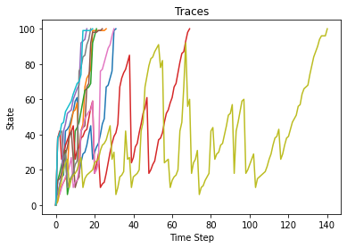

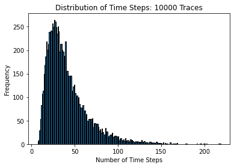

```python
num_traces = 10000

# Store the number of time steps in each trace
time_steps = []

# Plotting the traces
# We show just a few example traces on the plot for the traces (to see the patterns more clearly),
# but use a larger sampling for the histogram to get a sense of the distribution
for i in range(num_traces):
    trace_i = next(trace)
    states = [s.state for s in trace_i]
    time_steps.append(len(states))
    if i < 10:
        plt.plot(range(len(states)), states)


# Set the labels and title
plt.xlabel('Time Step')
plt.ylabel('State')
plt.title('Traces')

# Show the plot
plt.show()

# Plotting the distribution of time steps
plt.hist(time_steps, bins=range(min(time_steps), max(time_steps) + 1, 1), edgecolor='black')
plt.xlabel('Number of Time Steps')
plt.ylabel('Frequency')
plt.title(f"Distribution of Time Steps: {num_traces} Traces")

# Show the plot
plt.show()
```

### Part e

For the Snakes and Ladders game, calculate the expected number of rolls to finish the game. Hint: in order to calculate this, extend the Snakes and Ladders `FiniteMarkovProcess` to an appropriate `FiniteMarkovRewardProcess` instance. What should be the Rewards model in this MRP so you can use one of the methods in the `FiniteMarkovRewardProcess` class to determine the expected number of dice rolls to finish the game?

**We can set a uniform reward of +1 per step until termination. Then the expected number of steps until the end of the game is simply the expected return from the start state, state 0, with no discounting. We do not discount because each step is counted equally regardless of when it occurs (a 'legal' choice for this MRP, because it is episodic).**

**The expected return from state 0 is given simply by the value function applied to state 0, i.e., $V(0)$. The code below creates a Finite MRP with the same transition probabilities as our Finite MP above, but with a uniform reward of +1 per transition. It then assesses $V(0)$.**

```python
from typing import Tuple, Mapping, Dict
from rl.distribution import Categorical
from rl.markov_process import FiniteMarkovRewardProcess

def get_transition_reward_map(transition_map) -> Mapping[int, FiniteDistribution[Tuple[State[int], float]]]:
    """ Generate a transition reward map for a 100 square snakes and ladders board
    This code is adapted from the textbook example: InventoryMRP
    """
    d: Dict[State[int], Categorical[Tuple[int, float]]] = {}
    sr_probs_map = {}

    for state in transition_map.keys():
        sr_probs_map = {}
        next_states = transition_map[state]
        for next_state, prob in next_states:
            sr_probs_map[(next_state, 1)] = prob
        d[state] = Categorical(sr_probs_map)

    return d

SnakesFiniteMRP = FiniteMarkovRewardProcess(get_transition_reward_map(generate_transition_map()))
# print(SnakesFiniteMRP)
```

```python
# compute the value function for each state and save state 0's value function
expected_rolls = SnakesFiniteMRP.get_value_function_vec(gamma=1)[0]
print('The expected number of rolls to finish the game from state 0 is', expected_rolls)
```

```
The expected number of rolls to finish the game from state 0 is 39.02785951999369
```

## Question 2

Consider the problem of a frog jumping across a river with $n=9$ lilypads. The frog at every time step will randomly jump to a position in front of it (e.g. at the starting step, the frog will jump with $\frac{1}{10}$ probability to each of the lilypads or $\frac{1}{10}$ to the other side of the river). A diagram of the frog jumping problem is below.

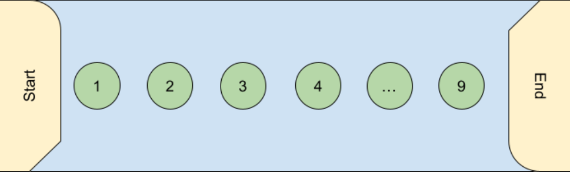

### Part a

Formalize the states of the jumping frog problem as well as the structure of the transition probabilites.

For that question. There are 11 states. We start from the terminal state: 0, as "End" position.  
Then, we treat other positions, start, 1, 2, ..., 9, as states with distance to End.  
So, we have those states: 10, 9, 8, 7, 6, 5, 4, 3, 2, 1, 0.

For every pair of i, j, transition probability p is defined in this  
P(i,j) = 0 if j >= i  
P(i,j) = 1/i if j < i  
(Notice that P(0, j) = 0 since every state is greater or equal to 0)

### Part b

Compute the expected number of steps that it would take for the frog to reach the other side.

We view the function of expected number of steps as f. First, it is obvious that  
f(1) = 1. It needs one step to 0 with probability of 1.  
Then, f(2) = 0.5 * 1 + 0.5 * (f(1)+1) = 3/2. Continue  
f(3) = 1/3 + (f(1)+1)/3 + (f(2)+1)/3 = 1 + (f(1)+f(2))/3 = 11/6  
It is obvious then:  
When i will not be 0, $ f(i)= \frac{1}{i} + \frac{(f(i-1)+1)}{i} + \frac{(f(i-2)+1)}{i} + ... \frac{(f(1)+1)}{i}= 1 + \frac{(f(1) + f(2) + ... + f(i-1))}{i}. $  
Calculate by hand or through a code, we will get the answer f(10) = 7381/2520 = 2.92897.  
. We need 2.92897 expected number of steps

### Part c

Provide a closed form solution for the expected number of steps / jumps to cross the river for arbitrary $n$. A formal proof is not required.

We extend our question to n. Suppose n = k. Thus, we have states: 0, 1, 2, 3, ..., k+1  
We notice that: the expected number of a state to get to the terminal state 0 is identical for all possible n. (As long as it is included).  
Since the expected number of a given states is only determined by how many states ahead, while the number of n only changes the number of states behind.  
Thus, given an arbitrary number n=k. Suppose the expected number of steps it needs under this case is m(k). Given the reasoning above:  
$m(k) = f(k+1) = 1 + \frac{f(1) + f(2) + ... + f(k)}{k+1} = 1 + \frac{m(0) + m(1) + ... + m(k-1)}{k+1}$  
In addition to that, we carefully review the first several answers of f. We notice that each denominator is the least common multiple of previous denominator and i. So we tried to decrease each consecutive pair, we found that f(i) - f(i-1) = 1/i.  
Thus, we can claim that m(n) = f(n+1) = $\sum_{i=1}^{n+1} \frac{1}{i} $. For an arbitrary n, we need $\sum_{i=1}^{n+1} \frac{1}{i} $ expected number of steps

Additional Proof: $f(i) - f(i-1) = \frac{1}{i} $  
We have already proved that $f(i) = 1 + \frac{f(1) + f(2) + ... + f(i-1)}{i}$ and $f(i-1) = 1 + \frac{f(1) + f(2) + ... + f(i-2)}{i-1}$  
Thus $f(1) + f(2) + ... + f(i-2) = (i-1)f(i-1)-i+1$ Plug back to $f(i)$  
$f(i) = 1 + \frac{(i-1)f(i-1)-i+1 + f(i-1)}{i} = 1 + f(i-1) - 1 + \frac{1}{i}$. We get $f(i) - f(i-1) = \frac{1}{i}$

## Question 3

Consider an MDP with an infinite set of states $\mathcal{S} = \{1,2,3,\ldots \}$. The start state is $s=1$. Each state $s$ allows a continuous set of actions $a \in [0,1]$. The transition probabilities are given by: $$\mathbb{P}[s+1 \mid s, a] = a, \mathbb{P}[s \mid s, a] = 1 - a \text{ for all } s \in \mathcal{S} \text{ for all } a \in [0,1]$$ For all states $s \in \mathcal{S}$ and actions $a \in [0,1]$, transitioning from $s$ to $s+1$ results in a reward of $1-a$ and transitioning from $s$ to $s$ results in a reward of $1+a$. The discount factor $\gamma=0.5$.

### Part a

Using the MDP Bellman Optimality Equation, calculate the Optimal Value Function $V^*(s)$ for all $s \in \mathcal{S}$

For every s in S. Apply the definition. $R(s,a) = EV(R_{t+1}|S_t=s, A_t=a) = (1-a)a + (1+a)(1-a) = (1-a)(1+2a)$  
$Q^*(s,a) = (1-a)(1+2a) + 0.5(aV^*(s+1) + (1-a)V^*(s))$  
Notice that, we can also get $Q^*(s+1,a) = (1-a)(1+2a) + 0.5(aV^*(s+2) + (1-a)V^*(s+1))$  
$V^*(s) = max_a Q^*(s,a)$.  
Due to stationary property and infinite number of states ahead. $V^*(s) = V^*(s+1)$.  
Thus, we get $Q^*(s,a) = (1-a)(1+2a) + 0.5V^*(s)$. To find the optimal a, we can find it through derivative.  
We find. When $a = \frac{1}{4}$, $Q^*(s,a)$, will get the max values.  
$V^*(s) = \frac{9}{4}$

### Part b

Calculate an Optimal Deterministic Policy $\pi^*(s)$ for all $s \in \mathcal{S}$

Given the reasoning above, I got $Q^*(s,a) = (1-a)(1+2a) + 0.5V^*(s)$. Find the maximum of Q under a by derivative. We get $1-4a = 0$. The a to make the maximum value is 0.25  
Given the definitions, $\pi^*(s) =argmax_a Q^*(s,a) = \frac{1}{4}$. The optimal deterministic policy is 0.25.

## Question 4

Consider again the problem of a frog jumping across a river with $n-1$ lilypads, labeled $1, \dots, n-1$, with the two riverbanks labeled positions $0$ and $n$. At each time step, the frog who is at lilypad $i$ has two options:

- (Strategy A) The frog moves to lilypad $i-1$ with probability $\frac{i}{n}$ and moves to lilypad $i+1$ otherwise.
- (Strategy B) The frog moves to arbitrary position from $0,\dots,n$ with equal probability.

The frog now starts on a random lilypad. A snake lives on one end of the river (say the snake lives at 0) and will eat the frog if it lands on this side of the river. The frog can escape by landing the other side of the river (i.e. position $n$). What should the frog's strategy be when on each of the lilypads $1, 2, \ldots, n-1$, in order to maximize the probability of escaping the pond (reaching $n$ before reaching $0$)? Although there are more than one ways of solving this problem, we would like to solve it by modeling it as an MDP and identifying the Optimal Policy.

Note: Sorry for all the frog jumping questions. These games are an easy way to understand Markov Processes, without having to build out too much detail of a financial simulation. Questions will be more related to finance over time.

### Part a

Express with clear mathematical notation the state space, the action space, transition function, and rewards function of an MDP so that the frog-escape problem would be solved by arriving at the Optimal Value Function (and hence, the Optimal Policy) of the MDP.

### Part b

Write code to model this MDP as an instance of the `FiniteMarkovDecisionProcess` class. We have learnt that there exists an optimal deterministic policy, and there are $2^{n-1}$ possible deterministic policies for this problem. Write code to create each of these $2^{n-1}$ deterministic policies (as instances of `FinitePolicy` class), create a policy-implied Finite MRP for each of these deterministic policies (using the `apply_finite_policy` method of `FiniteMarkovDecisionProcess` class), and evaluate the Value Function for each of those implied Finite MRPs (using the `get_value_function_vec` method of `FiniteMarkovRewardProcess` class). This should gives you the Optimal Value Function and the Optimal Deterministic Policy.

### Part c

Plot a graph of the Optimal Escape-Probability and of the associated strategies, as a function of the states of this MDP, for $n=3, n=6$ and $n=9$. By looking at the results on this graph, what pattern do you observe for the optimal policy as you vary $n$ from 3 to 9?

[figure not shown]